# Estadística Descriptiva Multivariada

Análisis de Correspondencias Simple — Paso a Paso

Jimmy A Corzo S, PhD

jacorzos@unal.edu.co

Giovany Babativa-Márquez, PhD

jgbabativam@unal.edu.co

# Ejemplo ACS

## Objetivos del análisis

1. Construir la tabla de contingencia y verificar asociación con $\chi^2$.
2. Calcular perfiles fila/columna y sus centroides.
3. Definir la **distancia $\chi^2$** entre perfiles.
4. Derivar la **matriz estandarizada** $\mathbf{Z}$ y la de sumas de cuadrados $\mathbf{Z}^\prime \mathbf{Z}$.
5. Extraer factores por descomposición en **valores propios**.
6. Obtener coordenadas vía **ecuaciones de transición**.
7. Generar el **plano factorial** con `ggplot2`.
8. Verificar con `FactoMineR`.
9. Calcular **contribuciones** y **cosenos cuadrados**.
10. Proyectar la variable suplementaria **`centro`**.

# Tabla de contingencia

## Frecuencias absolutas

Se simularon datos para **400 personas** de una institución de educación sobre su opinión respecto a una **reforma académica**.

```r
url <- "https://github.com/jgbabativam/EDM/raw/main/Datos/"
microdato <- read_sav(paste0(url, "ejemploACS.sav")) |>
             mutate(across(c("opinion", "grupo"), ~as_factor(.)))

tbl <- table(microdato$grupo, microdato$opinion)
```

Tabla de contingencia del grupo por opinión sobre la reforma

| Grupo | Totalmente en Contra | En Contra | A favor | Totalmente a favor | Sum |
| --- | --- | --- | --- | --- | --- |
| Estudiantes | 10 | 20 | 30 | 40 | 100 |
| Administrativos | 25 | 30 | 15 | 30 | 100 |
| Docentes | 85 | 20 | 15 | 80 | 200 |
| Sum | 120 | 70 | 60 | 150 | 400 |

**Note**

Los **Docentes** aportan 200 observaciones (50 % del total). ¿Existe una asociación entre la opinión y el grupo al que pertenecen los encuestados?

## Prueba de independencia $\chi^2$

$$H_0: f_{ij} = f_{i\cdot}\,f_{\cdot j} \quad \forall\, i,j \qquad H_1: \text{existe asociación}$$

```r
chi_test <- chisq.test(tbl)
chi_test
```

```
    Pearson's Chi-squared test

data:  tbl
X-squared = 64.798, df = 6, p-value = 4.745e-12
```

**Important**

Con $\chi^2 = 64.8$, $gl = 6$ y $p < 0.001$, se rechaza $H_0$. Existe suficiente evidencia para afirmar que hay una **asociación** entre el grupo y la opinión. El ACS permitirá visualizar esa estructura de asociación en un plano de dos dimensiones.

## Tabla de frecuencias relativas

Cada frecuencia se divide por el total $n = 400$: $f_{ij} = n_{ij}/n$.

```r
n     <- sum(tbl)
F_mat <- as.matrix(tbl) / n       # frecuencias relativas fij
fi_   <- rowSums(F_mat)           # marginal fila fi.
f_j   <- colSums(F_mat)           # marginal columna f.j
```

Frecuencias relativas: fij = nij / n

| Grupo | Totalmente en Contra | En Contra | A favor | Totalmente a favor | f<sub>i·</sub> |
| --- | --- | --- | --- | --- | --- |
| Estudiantes | 0.0250 | 0.050 | 0.0750 | 0.100 | 0.25 |
| Administrativos | 0.0625 | 0.075 | 0.0375 | 0.075 | 0.25 |
| Docentes | 0.2125 | 0.050 | 0.0375 | 0.200 | 0.50 |
| f.j | 0.3000 | 0.175 | 0.1500 | 0.375 | 1.00 |

> Los **pesos de fila** $f_{i\cdot}$: Estudiantes = 0.25, Administrativos = 0.25, Docentes = **0.50**.  
> Los **pesos de columna** $f_{\cdot j}$: TC = 0.30, EC = 0.175, Af = 0.15, Taf = 0.375.  
> Estas marginales son los **centroides** y las ponderaciones de la distancia.

# Perfiles y centroides

## Perfiles fila y centroide

El **perfil fila** de la categoría $i$ normaliza por su marginal: $p_{ij} = f_{ij}/f_{i\cdot}$

```r
perf_fila <- sweep(F_mat, 1, fi_, "/")   # perfil fila: fij / fi.
```

Perfiles fila

| Grupo | Totalmente en Contra | En Contra | A favor | Totalmente a favor |
| --- | --- | --- | --- | --- |
| Estudiantes | 0.100 | 0.200 | 0.300 | 0.400 |
| Administrativos | 0.250 | 0.300 | 0.150 | 0.300 |
| Docentes | 0.425 | 0.100 | 0.075 | 0.400 |
| Centroide G_J | 0.300 | 0.175 | 0.150 | 0.375 |

> De esta forma se tiene en cuenta el peso de la fila, lo que permitirá calcular la distancia entre filas al haber eliminado el efecto del tamaño muestral.

> El **centroide** $G_J = (f_{\cdot 1},\ldots,f_{\cdot 4}) = (0.30,\;0.175,\;0.15,\;0.375)$ es el perfil promedio ponderado de todas las filas.

> Los Docentes se alejan del centroide en TC (0.425 vs 0.30) y los Estudiantes en Af (0.30 vs 0.15).

## Perfiles columna y centroide

El **perfil columna** de la categoría $j$: $q_{ij} = f_{ij}/f_{\cdot j}$

```r
perf_col <- sweep(F_mat, 2, f_j, "/")   # perfil columna: fij / f.j
```

Perfiles columna

| Grupo | Totalmente en Contra | En Contra | A favor | Totalmente a favor |
| --- | --- | --- | --- | --- |
| Estudiantes | 0.0833 | 0.2857 | 0.50 | 0.2667 |
| Administrativos | 0.2083 | 0.4286 | 0.25 | 0.2000 |
| Docentes | 0.7083 | 0.2857 | 0.25 | 0.5333 |

> Del mismo modo, el número de elementos por columnas no es igual.

> El **centroide** $G_I = (f_{1\cdot}, f_{2\cdot}, f_{3\cdot}) = (0.25,\;0.25,\;0.50)$ es la distribución promedio sobre grupos.

> La opinión “TC” concentra el 70.8 % en Docentes, muy lejos del 50 % esperado bajo independencia. El ACS mide cuánto se aleja cada perfil columna de $G_I$.

# Distancia $\chi^2$

## Distancia entre perfiles fila

La **distancia $\chi^2$** entre dos perfiles fila $i$ e $i'$ pondera cada diferencia por la inversa del marginal de columna:

$$d^2(i,\;i') = \sum_{j=1}^{J} \frac{1}{f_{\cdot j}} \left(\frac{f_{ij}}{f_{i\cdot}} - \frac{f_{i'j}}{f_{i'\cdot}}\right)^2$$

**Note**

> Si $f_{\cdot j}$ es pequeño (categoría rara), el peso es grande.

> Si $f_{\cdot j}$ es grande (categoría muy frecuente), el peso es pequeño

**Important**

En AC buscamos diferencias respecto de lo esperado bajo independencia. Una categoría muy frecuente no es tan informativa. En cambio, una categoría rara es más “selectiva”. Si un grupo tiene mucha más presencia de esa categoría de la esperada, eso revela una asociación fuerte.

## Distancia entre estudiantes y docentes

**Perfiles fila**:

Perfiles fila

| Grupo | Totalmente en Contra | En Contra | A favor | Totalmente a favor |
| --- | --- | --- | --- | --- |
| Estudiantes | 0.100 | 0.200 | 0.300 | 0.400 |
| Administrativos | 0.250 | 0.300 | 0.150 | 0.300 |
| Docentes | 0.425 | 0.100 | 0.075 | 0.400 |
| Centroide G_J | 0.300 | 0.175 | 0.150 | 0.375 |

$$d^2(\text{Est},\,\text{Doc}) = \frac{(0.10-0.425)^2}{0.30} + \frac{(0.20-0.10)^2}{0.175} + \frac{(0.30-0.075)^2}{0.15} + \frac{(0.40-0.40)^2}{0.375} = 0.747$$

```r
d2_est_doc <- sum((perf_fila["Estudiantes", ] - perf_fila["Docentes", ])^2 / f_j)
cat("d²(Estudiantes, Docentes) =", round(d2_est_doc, 5),
    "\n d(Estudiantes, Docentes) =", round(sqrt(d2_est_doc), 5))
```

```
d²(Estudiantes, Docentes) = 0.74673
 d(Estudiantes, Docentes) = 0.86413
```

**Note**

El último término es cero: ambos grupos tienen la misma proporción en “Totalmente a favor” (40 %). La mayor discrepancia es en “TC” donde los Docentes cuadruplican la proporción de los Estudiantes (42.5 % vs 10 %).

## Distancia entre perfiles columna

De forma análoga, la distancia entre dos perfiles columna pondera con los **pesos de fila** $f_{i\cdot}$:

$$d^2(j,\;j') = \sum_{i=1}^{I} \frac{1}{f_{i\cdot}} \left(\frac{f_{ij}}{f_{\cdot j}} - \frac{f_{ij'}}{f_{\cdot j'}}\right)^2$$

```r
d2_col <- function(j1, j2)
  sum((perf_col[, j1] - perf_col[, j2])^2 / fi_)

cat("d²(TC, Af)  =", round(d2_col("Totalmente en Contra", "A favor"), 5))
```

```
d²(TC, Af)  = 1.12153
```

```r
cat("\n d(TC, Af)  =", round(sqrt(d2_col("Totalmente en Contra", "A favor")), 5))
```

```
 d(TC, Af)  = 1.05902
```

**Note**

“TC” concentra el 70.8 % en Docentes y solo el 8.3 % en Estudiantes; “Af” invierte el patrón (50 % en Estudiantes). Sus perfiles son casi opuestos, es decir, distancia grande.

## Matriz de coordenadas centradas $\mathbf{H}$

La **coordenada centrada** $h_{ij}$ mide la desviación de $f_{ij}$ respecto a lo esperado bajo independencia:

$$h_{ij} = f_{ij} - f_{i\cdot} f_{\cdot j}$$

```r
H <- F_mat - outer(fi_, f_j)   # H = F - fi.f.j
round(H, 5)
```

```
                  Totalmente en Contra En Contra  A favor Totalmente a favor
  Estudiantes                 -0.05000   0.00625  0.03750            0.00625
  Administrativos             -0.01250   0.03125  0.00000           -0.01875
  Docentes                     0.06250  -0.03750 -0.03750            0.01250
```

**Note**

$h_{ij} > 0$: el grupo $i$ eligió la opinión $j$ más de lo esperado bajo independencia. $h_{ij} < 0$: menos de lo esperado. Los Docentes presentan el mayor exceso en TC (+0.0625) y el mayor déficit en Af (−0.0375).

## Matriz estandarizada $\mathbf{Z}$

Estandarizando $\mathbf{H}$ por la raíz del producto de marginales:

$$z_{ij} = \frac{f_{ij} - f_{i\cdot}\,f_{\cdot j}}{\sqrt{f_{i\cdot}\,f_{\cdot j}}}$$

```r
W <- sqrt(outer(fi_, f_j))   # denominador: sqrt(fi. * f.j)
Z <- H / W                   # Z matriz estandarizada
round(Z, 5)
```

```
                  Totalmente en Contra En Contra  A favor Totalmente a favor
  Estudiantes                 -0.18257   0.02988  0.19365            0.02041
  Administrativos             -0.04564   0.14940  0.00000           -0.06124
  Docentes                     0.16137  -0.12677 -0.13693            0.02887
```

> **Inercia total:** $T = \displaystyle\sum_{ij} z_{ij}^2 = \chi^2/n$. Verificación: $\sum z_{ij}^2 = 0.16199$ y $\chi^2/n = 64.79762/400 = 0.16199$.

# Extracción de factores

## Análogo de la matriz de varianzas y covarianzas

Los factores se obtienen de la descomposición en valores propios de:

$$\mathbf{S} = \mathbf{Z}'\mathbf{Z}$$

```r
S <- t(Z) %*% Z
round(S, 6)
```

```
                       Totalmente en Contra En Contra   A favor
  Totalmente en Contra             0.061458 -0.032733 -0.057452
  En Contra                       -0.032733  0.039286  0.023146
  A favor                         -0.057452  0.023146  0.056250
  Totalmente a favor               0.003727 -0.012199  0.000000

                       Totalmente a favor
  Totalmente en Contra           0.003727
  En Contra                     -0.012199
  A favor                        0.000000
  Totalmente a favor             0.005000
```

La ecuación característica $|\mathbf{S} - \lambda\,\mathbf{I}| = 0$ da los **valores propios** $\lambda_\alpha$ (inercia explicada por cada eje) y los **vectores propios** $\mathbf{v}_\alpha$ (orientación de cada factor en el espacio de columnas).

## Valores propios y vectores propios

```r
eig_S   <- eigen(S)
idx     <- which(eig_S$values > 1e-10)
lambdas <- eig_S$values[idx]            # valores propios no nulos
V_mat   <- eig_S$vectors[, idx]         # vectores propios (4 × 2)
rownames(V_mat) <- names(f_j)
colnames(V_mat) <- c("v1", "v2")

cat("Valores propios:\n"); print(round(lambdas, 7))
```

```
Valores propios:
```

```
[1] 0.1335792 0.0284149
```

```r
cat("\nVectores propios (columnas):\n"); print(round(V_mat, 5))
```

```
Vectores propios (columnas):
```

```
                           v1       v2
Totalmente en Contra  0.67586  0.12451
En Contra            -0.39421  0.80749
A favor              -0.62013 -0.41444
Totalmente a favor    0.05699 -0.40087
```

```r
cat("\nSuma λ1 + λ2 =", round(sum(lambdas), 7),
    " = T =", round(sum(Z^2), 7))
```

```
Suma λ1 + λ2 = 0.161994  = T = 0.161994
```

## Importancia de los ejes

```r
pct_var <- lambdas / sum(lambdas) * 100
acum    <- cumsum(pct_var)
data.frame(Eje       = c("F1", "F2"),
           Lambda    = round(lambdas, 6),
           `% Inercia` = round(pct_var, 2),
           Acumulada = round(acum, 2))
```

```
  Eje   Lambda X..Inercia Acumulada
1  F1 0.133579      82.46     82.46
2  F2 0.028415      17.54    100.00
```

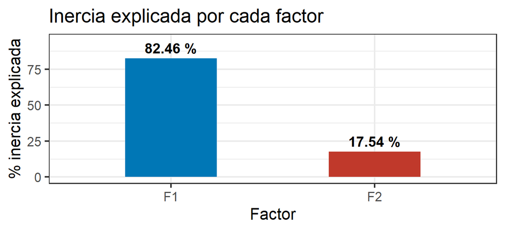

# Coordenadas en el espacio factorial

## Coordenadas de las categorías columna

Los vectores propios $\mathbf{v}_\alpha$ de $\mathbf{S} = \mathbf{Z}'\mathbf{Z}$ dan la **dirección** del $\alpha$-ésimo factor. Las **coordenadas principales** de las categorías columna son:

$$\mathbf{C} = \mathbf{D}_c^{-1/2}\,\mathbf{V}\,\mathbf{\Lambda}^{1/2} \qquad \Longleftrightarrow \qquad c_{j\alpha} = \frac{v_{j\alpha}}{\sqrt{f_{\cdot j}}}\,\sqrt{\lambda_\alpha}$$

```r
D_c_inv_sq <- diag(1 / sqrt(f_j))                          # D_c^{-1/2}
C_coord    <- D_c_inv_sq %*% V_mat %*% diag(sqrt(lambdas)) # C (4 × 2)
rownames(C_coord) <- names(f_j)
colnames(C_coord) <- c("F1", "F2")
```

```r
round(C_coord, 5)
```

```
                           F1       F2
Totalmente en Contra  0.45099  0.03832
En Contra            -0.34441  0.32538
A favor              -0.58520 -0.18038
Totalmente a favor    0.03401 -0.11035
```

## Coordenadas columna

Coordenadas de las columnas

| Opinión | F1 | F2 |
| --- | --- | --- |
| Totalmente en Contra | 0.45099 | 0.03832 |
| En Contra | -0.34441 | 0.32538 |
| A favor | -0.58520 | -0.18038 |
| Totalmente a favor | 0.03401 | -0.11035 |

**Note**

## Ecuaciones de transición

Las coordenadas de filas y columnas están relacionadas a través de los perfiles:

$$\boxed{r_{i\alpha} = \frac{1}{\sqrt{\lambda_\alpha}}\sum_{j=1}^{J} p_{ij}\,c_{j\alpha}} \qquad \text{(filas desde columnas)}$$

$$\boxed{c_{j\alpha} = \frac{1}{\sqrt{\lambda_\alpha}}\sum_{i=1}^{I} q_{ij}\,r_{i\alpha}} \qquad \text{(columnas desde filas)}$$

donde $p_{ij} = f_{ij}/f_{i\cdot}$ (perfil fila) y $q_{ij} = f_{ij}/f_{\cdot j}$ (perfil columna).

> La coordenada de una fila sobre el eje $\alpha$ es el **promedio ponderado** de las coordenadas de las columnas, usando como pesos el perfil fila de esa categoría. Esta relación es también la base para proyectar **categorías suplementarias**.

## Coordenadas fila vía ecuaciones de transición

$$r_{i\alpha} = \frac{1}{\sqrt{\lambda_\alpha}}\;\mathbf{p}_{i\cdot}\,\mathbf{c}_{\cdot\alpha}$$

```r
R_coord <- matrix(0, nrow = 3, ncol = 2,
                  dimnames = list(rownames(tbl), c("F1", "F2")))
for (a in 1:2) {
  R_coord[, a] <- (perf_fila %*% C_coord[, a]) / sqrt(lambdas[a])
}
round(R_coord, 5)
```

```
                      F1       F2
Estudiantes     -0.50820 -0.17409
Administrativos -0.18647  0.27901
Docentes         0.34733 -0.05246
```

Proyección usando los vectores propios de $\mathbf{Z}\mathbf{Z}'$:

```r
eig_row   <- eigen(Z %*% t(Z))  # Z*Z'
U_mat     <- eig_row$vectors[, 1:2]
R_directo <- diag(1/sqrt(fi_)) %*% U_mat %*% diag(sqrt(lambdas))
rownames(R_directo) <- rownames(tbl); colnames(R_directo) <- c("F1","F2")
round(R_directo, 5)
```

```
                      F1       F2
Estudiantes     -0.50820 -0.17409
Administrativos -0.18647  0.27901
Docentes         0.34733 -0.05246
```

## Plano factorial con `ggplot2`

- Plano
- Código

[figure not shown]

```r
df_f <- as.data.frame(R_coord) |>
  rownames_to_column("Cat") |>
  mutate(tipo = "Grupo (fila)")

df_c <- as.data.frame(C_coord) |>
  rownames_to_column("Cat") |>
  mutate(tipo = "Opinión (columna)")

ggplot(bind_rows(df_f, df_c),
       aes(F1, F2, color = tipo, label = Cat)) +
  geom_hline(yintercept = 0,
             linetype = "dashed",
             color = "gray60") +
  geom_vline(xintercept = 0,
             linetype = "dashed",
             color = "gray60") +
  geom_point(size = 3.5) +
  geom_text_repel(size = 4.5,
                  fontface = "bold",
                  max.overlaps = 20) +
  scale_color_manual(values = c("#0077b6", "#C0392B"),
                     name = "") +
  labs(
    title = "Plano factorial ACS del Grupo por Opinión sobre la reforma",
    x = paste0("F1 (", round(pct_var[1], 1), " %)"),
    y = paste0("F2 (", round(pct_var[2], 1), " %)")
  ) +
  theme_bw(base_size = 13) +
  theme(legend.position = "bottom")
```

# Verificación con `FactoMineR`

## Ajuste con `CA()`

```r
acs <- CA(as.data.frame.matrix(tbl), graph = FALSE)
cat("Valores propios (FactoMineR):\n")
```

```
Valores propios (FactoMineR):
```

```r
round(get_eigenvalue(acs), 5)
```

```
      eigenvalue variance.percent cumulative.variance.percent
Dim.1    0.13358         82.45931                    82.45931
Dim.2    0.02841         17.54069                   100.00000
```

```r
cat("Coordenadas fila (FactoMineR):\n"); round(acs$row$coord[,1:2], 4)
```

```
Coordenadas fila (FactoMineR):
```

```
                  Dim 1   Dim 2
Estudiantes      0.5082 -0.1741
Administrativos  0.1865  0.2790
Docentes        -0.3473 -0.0525
```

## Comparación manual vs `FactoMineR`

**Cálculo manual: Filas**

```
                     F1      F2
Estudiantes     -0.5082 -0.1741
Administrativos -0.1865  0.2790
Docentes         0.3473 -0.0525
```

**FactoMineR: Filas**

```
                  Dim 1   Dim 2
Estudiantes      0.5082 -0.1741
Administrativos  0.1865  0.2790
Docentes        -0.3473 -0.0525
```

**Cálculo manual: Columnas**

```
                          F1      F2
Totalmente en Contra  0.4510  0.0383
En Contra            -0.3444  0.3254
A favor              -0.5852 -0.1804
Totalmente a favor    0.0340 -0.1103
```

**FactoMineR: Columnas**

```
                       Dim 1   Dim 2
Totalmente en Contra -0.4510  0.0383
En Contra             0.3444  0.3254
A favor               0.5852 -0.1804
Totalmente a favor   -0.0340 -0.1103
```

**Note**

Las coordenadas coinciden en magnitud. Es posible que se presenten diferencias de **signo** (el signo del vector propio es arbitrario) y no afectan la interpretación de la configuración relativa.

## Biplot con `factoextra`

```r
fviz_ca_biplot(acs, repel = TRUE,
               col.row = "#0077b6", col.col = "#C0392B",
               title = "ACS del Grupo por Opinión sobre la reforma") +
  theme_bw()
```

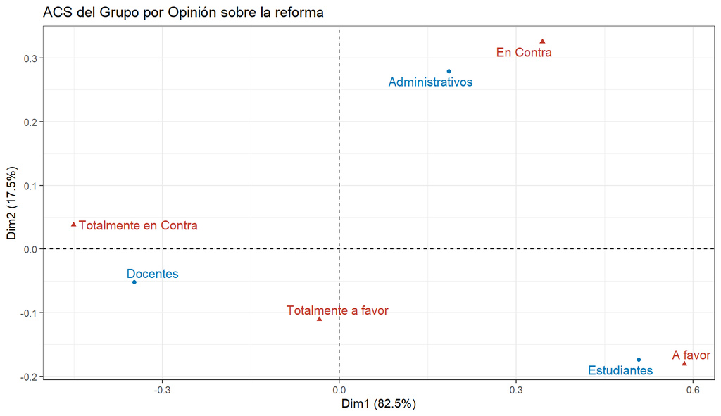

# Contribuciones y calidad de representación

## Coseno cuadrado: interpretación geométrica

La **calidad de representación** de la categoría $i$ sobre el factor $\alpha$ mide qué fracción de su distancia total al centroide queda capturada por ese eje:

$$\cos^2_\alpha(i) = \frac{r_{i\alpha}^2}{d^2(i,\,G_I)} = \frac{r_{i\alpha}^2}{\displaystyle\sum_{\alpha'} r_{i\alpha'}^2}$$

En el triángulo rectángulo, $r_{i\alpha}$ es el **cateto adyacente** (proyección sobre $F_\alpha$) y $d(i,G)$ la **hipotenusa** (distancia total al centroide):
$$\cos\theta_{i\alpha} = \frac{r_{i\alpha}}{d(i,\,G)} \implies \cos^2\theta_{i\alpha} = \frac{r_{i\alpha}^2}{r_{i1}^2 + r_{i2}^2}$$

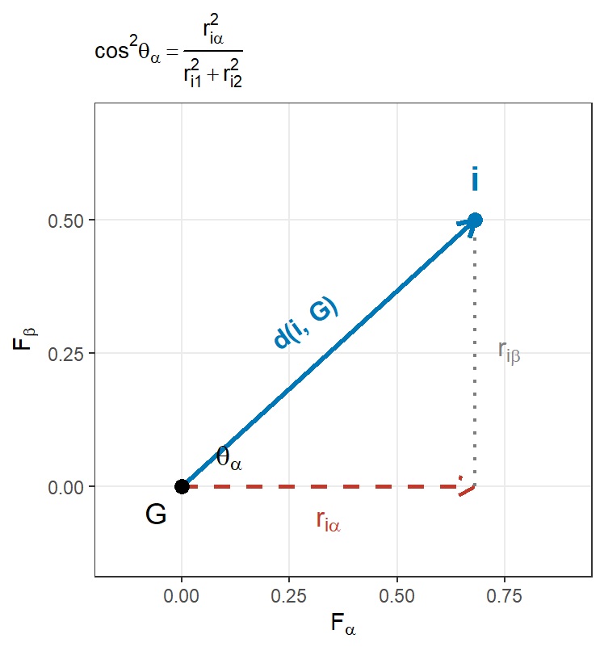

## Contribuciones de las filas

La **contribución** de la fila $i$ al factor $\alpha$ es la proporción de inercia del eje que aporta:

$$C_\alpha(i) = \frac{f_{i\cdot}\;r_{i\alpha}^2}{\lambda_\alpha} \times 100\;\%$$

| Grupo | Coordenadas F1 | Coordenadas F2 | Contribuciones (%) F1 | Contribuciones (%) F2 | Cos² F1 | Cos² F2 |
| --- | --- | --- | --- | --- | --- | --- |
| Estudiantes | 0.508 | -0.174 | 48.34 | 26.66 | 0.895 | 0.105 |
| Administrativos | 0.186 | 0.279 | 6.51 | 68.49 | 0.309 | 0.691 |
| Docentes | -0.347 | -0.052 | 45.16 | 4.84 | 0.978 | 0.022 |

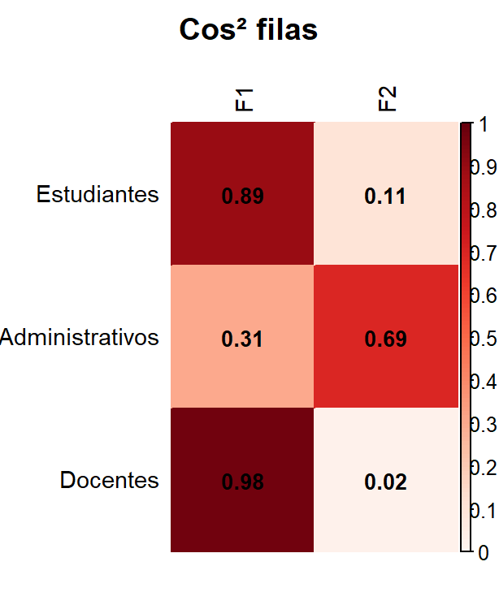

## Contribuciones de las columnas

| Opinión | Coordenadas F1 | Coordenadas F2 | Contribuciones (%) F1 | Contribuciones (%) F2 | Cos² F1 | Cos² F2 |
| --- | --- | --- | --- | --- | --- | --- |
| Totalmente en Contra | -0.451 | 0.038 | 45.68 | 1.55 | 0.993 | 0.007 |
| En Contra | 0.344 | 0.325 | 15.54 | 65.20 | 0.528 | 0.472 |
| A favor | 0.585 | -0.180 | 38.46 | 17.18 | 0.913 | 0.087 |
| Totalmente a favor | -0.034 | -0.110 | 0.32 | 16.07 | 0.087 | 0.913 |

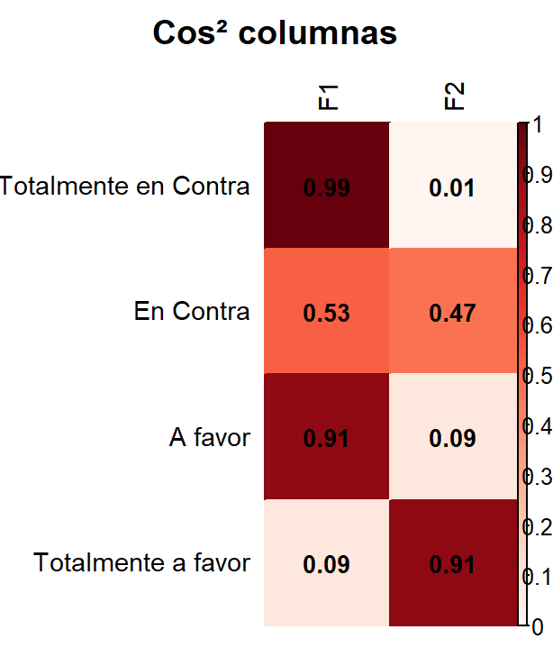

**Note**

Como los 2 ejes explican el 100% de la inercia, $\cos^2_{F1}(i) + \cos^2_{F2}(i) = 1$ para todos los puntos. Una contribución alta indica que la categoría **tipifica** el eje; un cos² alto indica que el eje la **representa bien**.

# Variables suplementarias

## ¿Qué es una variable suplementaria?

Una **variable suplementaria** no participa en la definición de los factores pero se proyecta en el espacio ya construido para enriquecer la interpretación.

Sea $s$ una **fila suplementaria** con perfil $\left(f_{sj}/f_{s\cdot}\right)$. Su coordenada sobre el factor $\alpha$ se obtiene con la misma ecuación de transición:

$$\boxed{r_{s\alpha} = \frac{1}{\sqrt{\lambda_\alpha}}\sum_{j=1}^{J}\frac{f_{sj}}{f_{s\cdot}}\;c_{j\alpha}}$$

Análogamente, para una **columna suplementaria** con perfil $\left(f_{is}/f_{\cdot s}\right)$:

$$c_{s\alpha} = \frac{1}{\sqrt{\lambda_\alpha}}\sum_{i=1}^{I}\frac{f_{is}}{f_{\cdot s}}\;r_{i\alpha}$$

> Las variables suplementarias obtienen **coordenadas** y **cos²**, pero **no contribuciones** (no participaron en la construcción de los ejes).

## Perfiles fila: centro educativo por opinión

```r
tbl_centro <- table(microdato$centro, microdato$opinion)
tbl_centro
```

```
          Totalmente en Contra En Contra A favor Totalmente a favor
  Privado                   60        30      40                140
  Publico                   60        40      20                 10
```

```r
n_centro  <- rowSums(tbl_centro)
perf_supl <- sweep(as.matrix(tbl_centro), 1, n_centro, "/")
round(perf_supl, 4)
```

```
          Totalmente en Contra En Contra A favor Totalmente a favor
  Privado               0.2222    0.1111  0.1481             0.5185
  Publico               0.4615    0.3077  0.1538             0.0769
```

**Note**

El **Privado** concentra el 51.9 % en “Totalmente a favor” y solo el 22.2 % en “TC”. El **Público** muestra el patrón opuesto: 46.2 % en “TC” y apenas 7.7 % en “Taf”. Sus perfiles son muy distintos entonces deben aparecer alejados en el plano. Veremos que la separación principal ocurre en **F2**, ya que ambos mezclan TC y Taf de forma que sus proyecciones sobre F1 se compensan.

## Proyección manual de la variable suplementaria

Aplicando la ecuación de transición con las coordenadas columna ya obtenidas:

$$r_{s\alpha} = \frac{1}{\sqrt{\lambda_\alpha}}\;\mathbf{p}_{s\cdot}\,\mathbf{c}_{\cdot\alpha}$$

```r
R_supl <- matrix(0, nrow = 2, ncol = 2,
                 dimnames = list(rownames(perf_supl), c("F1", "F2")))
for (a in 1:2) {
  R_supl[, a] <- (perf_supl %*% C_coord[, a]) / sqrt(lambdas[a])
}
round(R_supl, 4)
```

```
             F1      F2
Privado -0.0194 -0.2330
Publico  0.0404  0.4839
```

**Note**

La mayor separación entre centros ocurre en **F2**: **Publico** (≈ +0.48) se asocia a “En Contra”; **Privado** (≈ −0.23) a “Totalmente a favor”. Ambos tienen coordenadas pequeñas en F1 porque sus perfiles mezclan TC y Taf en proporciones que se compensan mutuamente al proyectarse sobre ese eje.

## Verificación con `FactoMineR`

```r
tbl_full <- rbind(as.data.frame.matrix(tbl),
                  as.data.frame.matrix(tbl_centro))
acs_supl <- CA(tbl_full, row.sup = 4:5, graph = FALSE)

cat("Coordenadas suplementarias (FactoMineR):\n")
```

```
Coordenadas suplementarias (FactoMineR):
```

```r
round(acs_supl$row.sup$coord[, 1:2], 4)
```

```
          Dim 1   Dim 2
Privado  0.0194 -0.2330
Publico -0.0404  0.4839
```

Las coordenadas manuales y las de `FactoMineR` coinciden (salvo diferencias de signo en los ejes, que son algo común).

## Plano factorial con la variable suplementaria

- Plano
- Código

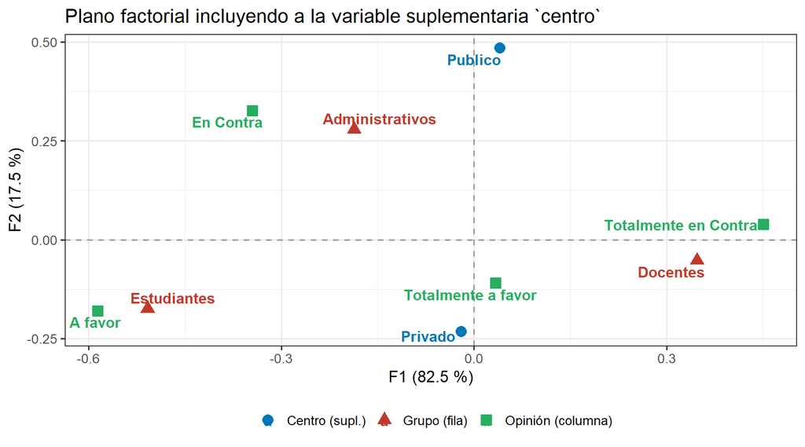

```r
df_f2 <- as.data.frame(R_coord) |>
  rownames_to_column("Cat") |>
  mutate(tipo = "Grupo (fila)")

df_c2 <- as.data.frame(C_coord) |>
  rownames_to_column("Cat") |>
  mutate(tipo = "Opinión (columna)")

df_s2 <- as.data.frame(R_supl) |>
  rownames_to_column("Cat") |>
  mutate(tipo = "Centro (supl.)")

bind_rows(df_f2, df_c2, df_s2) |>
  ggplot(aes(F1, F2,
             color = tipo,
             shape = tipo,
             label = Cat)) +
  geom_hline(yintercept = 0,
             linetype = "dashed",
             color = "gray60") +
  geom_vline(xintercept = 0,
             linetype = "dashed",
             color = "gray60") +
  geom_point(size = 3.8) +
  geom_text_repel(size = 4.2,
                  fontface = "bold",
                  max.overlaps = 20) +
  scale_color_manual(
    values = c("#0077b6", "#C0392B", "#27AE60"),
    name = ""
  ) +
  scale_shape_manual(
    values = c(16, 17, 15),
    name = ""
  ) +
  labs(
    title = "Plano factorial incluyendo a la variable suplementaria `centro`",
    x = paste0("F1 (", round(pct_var[1], 1), " %)"),
    y = paste0("F2 (", round(pct_var[2], 1), " %)")
  ) +
  theme_bw(base_size = 13) +
  theme(legend.position = "bottom")
```

# Interpretación

## Lectura del Factor 1 ($82.5$ % de la inercia)

- **F1** captura el mayor contraste: **“Totalmente en Contra”** (coord. positiva alta ≈ +0.45) y los **Docentes** (+0.35) en el extremo positivo; **“A favor”** (≈ −0.59) y **“En Contra”** (≈ −0.34) en el extremo negativo.
- Los **Estudiantes** (≈ −0.51) se ubican del lado de las opciones favorables/moderadas; los **Docentes** del lado del rechazo total.
- **“Totalmente a favor”** queda cerca del origen en F1 (≈ +0.03): su perfil es mixto (Docentes y Estudiantes lo comparten) y no discrimina tanto en este eje.
- Los **Administrativos** (≈ −0.19) están levemente del lado favorable/moderado; su perfil de respuesta se aleja poco del centroide en la dirección de F1.

## Lectura del Factor 2 ($17.5$ % de la inercia)

**Note**

Como los 2 ejes explican el **100 % de la inercia**, los cos² suman exactamente 1 para todo punto. El plano factorial es la representación **exacta** de la nube de puntos sin ninguna pérdida de información.

## Resumen

- La prueba $\chi^2$ confirma la **asociación significativa** ($p < 0.001$) entre grupo y opinión.
- Un plano con 2 dimensiones permite la representación **exacta**, sin pérdida de información.
- **F1** (82.5 %) opone el rechazo total (TC — Docentes) a las posiciones moderadas y favorables (EC, Af — Estudiantes y Administrativos).
- **F2** (17.5 %) diferencia “En Contra” de “Totalmente a favor”, y sitúa a Administrativos cerca de la categoría “En Contra”.
- La cercanía entre **“Totalmente en Contra”** y **“Docentes”** revela fuerte asociación: los Docentes encabezan el rechazo a la reforma.
- La **variable suplementaria** `centro` aporta contexto: el Privado se vincula a “Totalmente a favor” (F2 negativo); el Público a “En Contra” (F2 positivo).

**Important**

**Regla práctica:** priorizar puntos **alejados del origen** con **contribución alta** y **cos² alto** ya que son los que más definen los ejes y están mejor representados en el plano.

# GRACIAS!

## Citación y derechos de autor

Este material fue elaborado por **Jimmy Corzo** y **Giovany Babativa-Márquez** y se distribuye bajo la licencia **Creative Commons Atribución-CompartirIgual 4.0 Internacional (CC BY-SA 4.0)**.

**Citación sugerida**

> Corzo, J., & Babativa-Márquez, J. G. (2026). *Materiales del curso Estadística Descriptiva Multivariada* (Versión 2026-1). Zenodo. https://doi.org/10.5281/zenodo.21730142

**Repositorio GitHub:** https://github.com/jgbabativam/EDM

**Sitio web del curso:** https://jgbabativam.github.io/EDM

**Licencia:** https://creativecommons.org/licenses/by-sa/4.0/

**Versión del material:** 2026-1 • **Última actualización:** Julio de 2026